# Differenciation among *Crepidostomum* populations

J. Ignacio Lucas Lledó

2025-05-19

```r
Crepido <- read.table('../../data/IDs/Crepido_fish_IDs_all_data_2021Dec.txt')
SamplesWithData <- setdiff(
  sub('.bam', '', grep('.bam$', dir('../2024-10-04/BAM'), value = TRUE)),
  scan('../2024-10-04/BadGuys.txt', what = 'character')
)
Crepido <- Crepido[Crepido$P_code %in% SamplesWithData, ]
Crepido$Date <- as.Date(Crepido$Date, format = '%d.%m.%y')
table(Crepido[, c('Lake', 'Sci_name_CONSENSUS_ID')])
```

```
##                Sci_name_CONSENSUS_ID
## Lake             L  P
##   Langfjordvatn 37  2
##   Suopatjavri   51  0
```

```r
table(Crepido[, c('Lake', 'Sex')])
```

```
##                Sex
## Lake             f  m
##   Langfjordvatn 16 22
##   Suopatjavri   18 28
```

We only have samples with data from Langfjordvatn and Suopatjavri. Most of them come from *L* fish, and only two from *P* fish. Thus, there is no point in attempting an estimation of $F_{ST}$ between the two ecomorphs. If anything, we can estimate $F_{ST}$s between lakes and between sexes. Dates of collection and dissection are very evenly distributed along september, 2017. Note that only 84 (instead of 90) parasites were found on fish with sex assigned. There are 6 individuals whose host is of unknown sex.

Considering results in `2024-10-05`, we have two putative species, one predominating in each lake. The most meaningful comparison is that between individuals of one putative species in one lake and individuals of the other putative species in the other lake. I will make some additional comparisons, just as negative controls.

```r
structure <- read.table('../2024-10-05/summary.txt', header = TRUE)
sp1 <- structure[structure$K2.1 > 0.95, 'Sample']
sp2 <- structure[structure$K2.2 > 0.95, 'Sample']
unk <- structure[structure$K2.1 < 0.95 & structure$K2.2 < 0.95, 'Sample']
Crepido$Species <- factor(NA, levels = c('sp1', 'sp2', 'unk'))
Crepido[Crepido$P_code %in% sp1, 'Species'] <- 'sp1'
Crepido[Crepido$P_code %in% sp2, 'Species'] <- 'sp2'
Crepido[Crepido$P_code %in% unk, 'Species'] <- 'unk'
byLakeSexSpecies <- split(Crepido$P_code, Crepido[, c('Lake', 'Sex', 'Species')])
null <- lapply(names(byLakeSexSpecies), function(x) {
   if (length(byLakeSexSpecies[[x]]) > 4) {
      write.table(paste0('../2024-10-04/BAM/', byLakeSexSpecies[[x]], '.bam'),
                  paste0(x, '.list'), quote = FALSE,
                  row.names = FALSE, col.names = FALSE)
   }
})
write.table(paste0('../2024-10-04/BAM/',
                   Crepido[Crepido$Lake == 'Langfjordvatn' & Crepido$Species == 'sp2', 'P_code'],
                   '.bam'),
            'Langfjordvatn.list',
            quote = FALSE, row.names = FALSE, col.names = FALSE)
write.table(paste0('../2024-10-04/BAM/',
                   Crepido[Crepido$Lake == 'Suopatjavri' & Crepido$Species == 'sp1', 'P_code'],
                   '.bam'),
            'Suopatjavri.list',
            quote = FALSE, row.names = FALSE, col.names = FALSE)
```

To be run in Garnatxa:

```bash
ASM=../2024-10-04/radloci.fa

if [ ! -d SAF ]; then mkdir SAF; fi
for pop in $(ls -1 *.list); do
   NUMIND=$(cat $pop | wc -l)
   NAME=$(basename -s .list $pop)
   if [ ! -e SAF/$NAME.saf.idx ]; then
      angsd -b $pop \
            -anc $ASM \
            -ref $ASM \
            -out SAF/$NAME \
            -doSaf 1 \
            -doGlf 1 \
            -gl 1 \
            -minMapQ 30 \
            -minQ 20 \
            -only_proper_pairs 1 \
            -baq 1 \
            -minInd $(( NUMIND * 4 /  5)) \
            -setMinDepthInd 4 \
            -nThreads 4 1> SAF/$NAME.log 2> SAF/$NAME.err &
   fi
done
wait
```

From the whole-genome SAF files, I generate below the SFS for a visualization and comparison among populations. We don’t really need individual SFS for $F_{ST}$ calculation, but we need it for other purposes. This is run in Garnatxa as well, with the same script.

```bash
if [ ! -d SFS ]; then mkdir SFS; fi
for pop in $(ls -1 *.list); do
   NAME=$(basename -s .list $pop)
   if [ ! -e SFS/$NAME.sfs ]; then
      realSFS -fold 1 \
              -nSites 5000000 \
              SAF/$NAME.saf.idx 1> SFS/$NAME.sfs 2> SFS/$NAME.log
   fi
   # If the EM optimization is repeated, due to instability detected,
   # more than one SFS is output, in different lines. We need to keep
   # only the last one.
   if [ $(cat SFS/$NAME.sfs | wc -l) -gt 1 ]; then
      mv SFS/$NAME.sfs SFS/$NAME.sfs_multiple
      tail -n 1 SFS/$NAME.sfs_multiple > SFS/$NAME.sfs
   fi
done
```

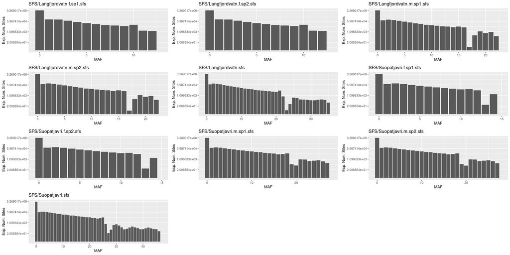

```r
suppressMessages(library(ggplot2))
suppressMessages(library(gridExtra))
files <- system2('ls', args = 'SFS/*.sfs', stdout = TRUE)
sfs.list <- lapply(files, scan, quiet = TRUE)
names(sfs.list) <- gsub('(SFS/|.sfs)', '', files)
plots <- lapply(1:length(sfs.list), function(x) {
   SFS <- sfs.list[[x]]
   # I add 1 to expected number of sites to facilitate log transformation.
   ggplot(data = data.frame(X = 0:(length(SFS)-1), Y = SFS + 1),
          mapping = aes(x = X, y = Y)) +
      geom_col() +
      scale_y_continuous(trans = 'log') +
      ggtitle(files[x]) +
      xlim(-0.5, (length(SFS) + 1)/2) +
      xlab('MAF') + ylab('Exp. Num. Sites')
})
grid.arrange(grobs = plots, ncol = 3)
```

## Two-dimensional SFS

```bash
if [ ! -d 2D_SFS ]; then mkdir 2D_SFS; fi
# In alphabetic order
POPS=(Langfjordvatn.f.sp1 Langfjordvatn.m.sp1 Langfjordvatn Suopatjavri.f.sp2 Suopatjavri.m.sp2 Suopatjavri)
for j in $(seq 1 $(( ${#POPS[@]} - 1)) ); do
   for i in $(seq 0 $(( j - 1 )) ); do
      if [ ! -e 2D_SFS/${POPS[i]}.${POPS[j]}.ml ]; then
         realSFS -cores 32 \
                 -fold 1 \
                 -nSites 5000000 \
                 SAF/${POPS[i]}.saf.idx \
                 SAF/${POPS[j]}.saf.idx \
                 1> 2D_SFS/${POPS[i]}.${POPS[j]}.ml \
                 2> 2D_SFS/${POPS[i]}.${POPS[j]}.err
      fi
   done
done
```

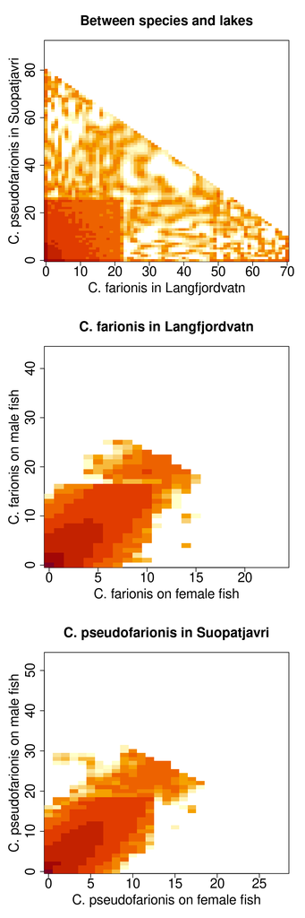

```r
Pop1 <- c('Langfjordvatn', 'Langfjordvatn.f.sp1', 'Suopatjavri.f.sp2')
Pop2 <- c('Suopatjavri',   'Langfjordvatn.m.sp1', 'Suopatjavri.m.sp2')
SFS2DFiles <- c('2D_SFS/Langfjordvatn.Suopatjavri.ml',
                '2D_SFS/Langfjordvatn.f.sp1.Langfjordvatn.m.sp1.ml',
                '2D_SFS/Suopatjavri.f.sp2.Suopatjavri.m.sp2.ml')
numInd <- sapply(c(Pop1, Pop2),
                 function(x) {
                    length(scan(paste0(x, '.list'),
                                what = 'character',
                                quiet = TRUE))
                 })
SFS2D <- lapply(1:length(SFS2DFiles),
                function(x) {
                   pop1 <- Pop1[x]
                   pop2 <- Pop2[x]
                   matrix(scan(SFS2DFiles[x], quiet = TRUE),
                          ncol = 2 * numInd[pop2] + 1,
                          nrow = 2 * numInd[pop1] + 1,
                          byrow = TRUE)
                })

MainLab <- c('Between species and lakes',
             'C. farionis in Langfjordvatn',
             'C. pseudofarionis in Suopatjavri')
XLabels <- c('C. farionis in Langfjordvatn',
             'C. farionis on female fish',
             'C. pseudofarionis on female fish')
YLabels <- c('C. pseudofarionis in Suopatjavri',
             'C. farionis on male fish',
             'C. pseudofarionis on male fish')
par(mfrow = c(3, 1), mar = c(5.5, 5.5, 5, 2))
devnull <- lapply(1:length(SFS2D), function(z) {
   image(x = 0:(dim(SFS2D[[z]])[1] - 1),
         y = 0:(dim(SFS2D[[z]])[2] - 1),
         log(SFS2D[[z]]),
         main = MainLab[z],
         xlab = XLabels[z],
         ylab = YLabels[z],
         cex.main = 2, cex.lab = 2, cex.axis = 2)
})
```

```r
par(mfrow = c(1, 1), mar = c(5.1, 4.1, 4.1, 2.1))
```

## $F_{ST}$s

```bash
POPS=(Langfjordvatn.f.sp1 Langfjordvatn.m.sp1 Langfjordvatn Suopatjavri.f.sp2 Suopatjavri.m.sp2 Suopatjavri)

if [ ! -d FST ]; then mkdir FST; fi
for j in $(seq 1 $(( ${#POPS[@]} - 1 )) ); do
   for i in $(seq 0 $(( j - 1 )) ); do
      if [ ! -e FST/${POPS[i]}.${POPS[j]}.fst.idx ]; then
         /home/joiglu/software/NGSTOOLS/angsd/misc/realSFS fst index \
                 SAF/${POPS[i]}.saf.idx \
                 SAF/${POPS[j]}.saf.idx \
                 -sfs 2D_SFS/${POPS[i]}.${POPS[j]}.ml \
                 -fstout FST/${POPS[i]}.${POPS[j]} \
                 -whichFst 1 \
                 -cores 8 \
                 1> FST/${POPS[i]}.${POPS[j]}.log \
                 2> FST/${POPS[i]}.${POPS[j]}.err
      fi
   done
done
```

```bash
if [ ! -e summaryFST.txt ]; then
   echo -e "Pop1\tPop2\tFST.unweighted\tFST.weighted" > summaryFST.txt
   if [ -e FST/Langfjordvatn.Suopatjavri.fst.idx ]; then
      LC_ALL=C printf "%s\t%s\t%.6f\t%.6f\n" \
      "C. farionis (Lan)" "C. pseudofarionis (Suo)" \
      $(realSFS fst stats FST/Langfjordvatn.Suopatjavri.fst.idx 2> /dev/null) >> summaryFST.txt
   else
      echo -e "C. farionis (Lan)\tC. pseudofarionis (Suo)\tNA\tNA" >> summaryFST.txt
   fi

   if [ -e FST/Langfjordvatn.f.sp1.Langfjordvatn.m.sp1.fst.idx ]; then
      LC_ALL=C printf "%s\t%s\t%.6f\t%.6f\n" \
      "C. farionis on females (Lan)" "C. farionis on males (Lan)" \
      $(realSFS fst stats FST/Langfjordvatn.f.sp1.Langfjordvatn.m.sp1.fst.idx 2> /dev/null) >> summaryFST.txt
   else
      echo -e "C. farionis on females (Lan)\tC. farionis on males (Lan)\tNA\tNA" >> summaryFST.txt
   fi

   if [ -e FST/Suopatjavri.f.sp2.Suopatjavri.m.sp2.fst.idx ]; then
      LC_ALL=C printf "%s\t%s\t%.6f\t%.6f\n" \
      "C. pseudofarionis on females (Suo)" "C. pseudofarionis on males (Suo)" \
      $(realSFS fst stats FST/Suopatjavri.f.sp2.Suopatjavri.m.sp2.fst.idx 2> /dev/null) >> summaryFST.txt
   else
      echo -e "C. pseudofarionis on females (Suo)\tC. pseudofarionis on males (Suo)\tNA\tNA" >> summaryFST.txt
   fi
fi
```

```r
library(kableExtra)
fsts <- read.table('summaryFST.txt', header = TRUE, sep = '\t')
kable(fsts) %>% kable_styling()
```

| Pop1 | Pop2 | FST.unweighted | FST.weighted |
| --- | --- | --- | --- |
| C. farionis (Lan) | C. pseudofarionis (Suo) | 0.022496 | 0.125520 |
| C. farionis on females (Lan) | C. farionis on males (Lan) | 0.000298 | -0.008964 |
| C. pseudofarionis on females (Suo) | C. pseudofarionis on males (Suo) | 0.000171 | -0.007581 |

```r
#ggplot(fsts, aes(x = FST.unweighted, y = FST.weighted)) + geom_point()
```